# InVivoStat Multivariate Principal Components Analysis

## Description

The following responses are included in the PCA analysis: Sepal length,Sepal width,Petal width,Petal length. Additionally, the responses have been centered at zero and are scaled to have unit variance.

## Summary results of principal components (PC)

|  | PC1 | PC2 | PC3 | PC4 |
| --- | --- | --- | --- | --- |
| Standard deviation | 1.7083 | 0.9561 | 0.3833 | 0.1440 |
| Proportion of variance | 0.7296 | 0.2285 | 0.0367 | 0.0052 |
| Cumulative proportion | 0.7296 | 0.9581 | 0.9948 | 1.0000 |

This table summarises the proportion of the total variance explained by each principal component.

## Plot of the proportion of the variance for each principal component

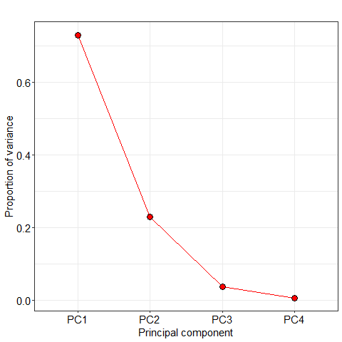

This plot illustrates the proportion of the variability explained by each principal component.

## Principal component loadings

|  | PC1 | PC2 | PC3 | PC4 |
| --- | --- | --- | --- | --- |
| Sepal length | 0.521 | -0.377 | 0.720 | 0.262 |
| Sepal width | -0.269 | -0.923 | -0.244 | -0.124 |
| Petal width | 0.565 | -0.067 | -0.635 | 0.523 |
| Petal length | 0.580 | -0.024 | -0.142 | -0.802 |

This table summarises the loadings of principal components. Responses with the larger absolute loadings have a greater influence on the corresponding principal component.

## Biplot of the first two principal components

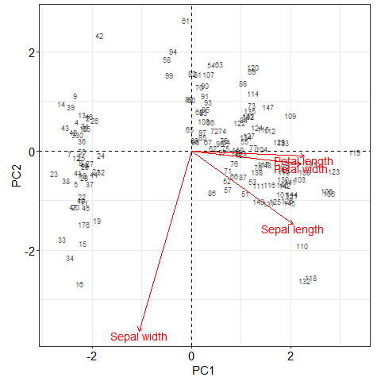

These axes are scaled to allow both loading and scores to be included on the same plot.

## Plot of the first two principal components, labelled by the Row ID variable

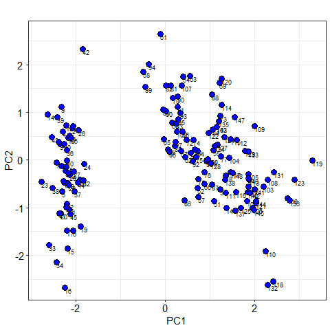

## References

When referring to InVivoStat, please cite 'InVivoStat, version 4.9'.

#### R references

R Development Core Team (2013). R: A language and environment for statistical computing. R Foundation for Statistical Computing, Vienna, Austria. URL http://www.R-project.org.

Lecoutre, Eric (2003). The R2HTML Package. R News, Vol 3. N. 3, Vienna, Austria.

Barret Schloerke, Di Cook, Joseph Larmarange, Francois Briatte, Moritz Marbach, Edwin Thoen, Amos Elberg and Jason Crowley (2021). GGally: Extension to 'ggplot2'. R package version 2.1.2. https://CRAN.R-project.org/package=GGally

Erich Neuwirth (2022). RColorBrewer: ColorBrewer Palettes. R package version 1.1-3. https://CRAN.R-project.org/package=RColorBrewer

H. Wickham. ggplot2: Elegant Graphics for Data Analysis. Springer-Verlag New York, 2016.

Kamil Slowikowski (2021). ggrepel: Automatically Position Non-Overlapping Text Labels with 'ggplot2'. R package version 0.9.1. https://CRAN.R-project.org/package=ggrepel

H. Wickham. Reshaping data with the reshape package. Journal of Statistical Software, 21(12), 2007.

Hadley Wickham (2011). The Split-Apply-Combine Strategy for Data Analysis. Journal of Statistical Software, 40(1), 1-29. URL https://www.jstatsoft.org/v40/i01/.

Hadley Wickham and Dana Seidel (2022). scales: Scale Functions for Visualization. R package version 1.2.1. https://CRAN.R-project.org/package=scales

Gabor Grothendieck, Louis Kates and Thomas Petzoldt (2016). proto: Prototype Object-Based Programming. R package version 1.0.0. https://CRAN.R-project.org/package=proto

Alan Genz, Frank Bretz, Tetsuhisa Miwa, Xuefei Mi, Friedrich Leisch, Fabian Scheipl, Torsten Hothorn (2021). mvtnorm: Multivariate Normal and t Distributions. R package version 1.1-3. URL http://CRAN.R-project.org/package=mvtnorm

## Analysis dataset

| Observation | Sepal length | Sepal width | Petal length | Petal width | Cases |
| --- | --- | --- | --- | --- | --- |
| 1 | 5.1 | 3.5 | 1.4 | 0.2 | 1 |
| 2 | 4.9 | 3.0 | 1.4 | 0.2 | 2 |
| 3 | 4.7 | 3.2 | 1.3 | 0.2 | 3 |
| 4 | 4.6 | 3.1 | 1.5 | 0.2 | 4 |
| 5 | 5.0 | 3.6 | 1.4 | 0.3 | 5 |
| 6 | 5.4 | 3.9 | 1.7 | 0.4 | 6 |
| 7 | 4.6 | 3.4 | 1.4 | 0.3 | 7 |
| 8 | 5.0 | 3.4 | 1.5 | 0.2 | 8 |
| 9 | 4.4 | 2.9 | 1.4 | 0.2 | 9 |
| 10 | 4.9 | 3.1 | 1.5 | 0.1 | 10 |
| 11 | 5.4 | 3.7 | 1.5 | 0.2 | 11 |
| 12 | 4.8 | 3.4 | 1.6 | 0.2 | 12 |
| 13 | 4.8 | 3.0 | 1.4 | 0.1 | 13 |
| 14 | 4.3 | 3.0 | 1.1 | 0.1 | 14 |
| 15 | 5.8 | 4.0 | 1.2 | 0.2 | 15 |
| 16 | 5.7 | 4.4 | 1.5 | 0.4 | 16 |
| 17 | 5.4 | 3.9 | 1.3 | 0.4 | 17 |
| 18 | 5.1 | 3.5 | 1.4 | 0.3 | 18 |
| 19 | 5.7 | 3.8 | 1.7 | 0.3 | 19 |
| 20 | 5.1 | 3.8 | 1.5 | 0.3 | 20 |
| 21 | 5.4 | 3.4 | 1.7 | 0.2 | 21 |
| 22 | 5.1 | 3.7 | 1.5 | 0.4 | 22 |
| 23 | 4.6 | 3.6 | 1.0 | 0.2 | 23 |
| 24 | 5.1 | 3.3 | 1.7 | 0.5 | 24 |
| 25 | 4.8 | 3.4 | 1.9 | 0.2 | 25 |
| 26 | 5.0 | 3.0 | 1.6 | 0.2 | 26 |
| 27 | 5.0 | 3.4 | 1.6 | 0.4 | 27 |
| 28 | 5.2 | 3.5 | 1.5 | 0.2 | 28 |
| 29 | 5.2 | 3.4 | 1.4 | 0.2 | 29 |
| 30 | 4.7 | 3.2 | 1.6 | 0.2 | 30 |

[output cut: 120 more lines]

## Analysis options

Response variables: Sepal length,Sepal width,Petal width,Petal length

Analysis performed: Principal Components analysis

Response centering: Centered at zero

Response scale: Unit variance

Plot labels: Case ID